# FALL 2023 Ron Balaban & Folorunsho Atanda Final Project- Poverty

Ron Balaban

2023-10-29

### Data Preparation

Posit Cloud: https://posit.cloud/spaces/449020/content/7089697

### Research question

Has the overall wealth/poverty divide in the world changed for better or worse in the past ~30 years? How have certain factors affected the change?

### Cases

Each case is an individual recording of a country, when the poverty report was done, along with the ratio/amount of people living below a certain standard. There are 4877 cases.

### Data collection

The data was obtained from a public Kaggle dataset- https://www.kaggle.com/datasets/eishkaran/world-poverty-data

### Type of study

This is an observational study.

### Data Source

The data was obtained from a public Kaggle dataset- https://www.kaggle.com/datasets/eishkaran/world-poverty-data , which was sourced from the World Bank: https://www.worldbank.org/en/news/factsheet/2022/05/02/fact-sheet-an-adjustment-to-global-poverty-lines#2

### Dependent Variable

The response variables are headcount_ratio_international_povline, headcount_ratio_lower_mid_income_povline, headcount_ratio_upper_mid_income_povline, which are the ratio headlines.

Additionally we looked at the totals, which are headcount_international_povline, headcount_lower_mid_income_povline, headcount_upper_mid_income_povline, along with the mean income

### Independent Variable(s)

country, year, reporting_level, survey_year, total population (which we computed)

### Relevant summary statistics

**Provide summary statistics for each the variables. Also include appropriate visualizations related to your research question (e.g. scatter plot, boxplots, etc). This step requires the use of R, hence a code chunk is provided below. Insert more code chunks as needed.**

#Possibly needed libraries

```r
library(dplyr)
library(shiny)
library(tidyverse)
library(psych)
```

#Abstract & Introduction

For our final project, we decided to analyze historical data relating to global levels of poverty and income for the prior 30 years, which was collected by the World Bank in an effort by the United Nations to end poverty by 2030.

```
Our motivation for this analysis was to see how certain countries have changed in their poverty measures, and to see if there are any drivers for the changes in poverty lines, of which there are multiple, such as mean income and total population, and calculations methods.

This data, which ranges from 1967 to 2021, compares the values using a metric called Purchasing Power Parity (PPP), which is used to convert different currencies into a common, internationally comparable unit. This data accounts for both price differences, cost of living, and inflation across countries and regions. The poverty lines come in 3 levels- International Base Poverty, International Lower-Middle, and International Middle-Upper lines.

We decided to use the country, year, and PPP version as our independent variables, while the headcounts and ratios of the poverty levels, along with the mean income and total population as our dependent variables. The data itself is rather tidy, in that it is segmented by country, year, reporting level, and PPP version and includes the totals and ratios of the population living in certain levels of poverty.

After our analysis, we found that on a world-level, poverty is shrinking and income rising, but at different rates for certain countries, and regions, and that this trend coincides with the relationships we found between poverty, population, and mean income. This analysis is important since by analyzing our findings, we can provide actionable insights and potential causes for reducing poverty world-wide, at least on a broader scale.
```

#Data

#Load data and make into frame

```r
poverty_raw <- read.csv(url("https://raw.githubusercontent.com/RonBalaban/CUNY-SPS-R/main/pip_dataset.csv"))
poverty_frame <- as.data.frame(poverty_raw)

# Adding total population based on ratios
poverty_frame <- poverty_frame %>%
  mutate(Total_Population =  headcount_upper_mid_income_povline / headcount_ratio_upper_mid_income_povline)

head(poverty_frame)
```

```
##   country year reporting_level welfare_type ppp_version survey_year
## 1 Albania 1996        national  consumption        2011        1996
## 2 Albania 2002        national  consumption        2011        2002
## 3 Albania 2005        national  consumption        2011        2005
## 4 Albania 2008        national  consumption        2011        2008
## 5 Albania 2012        national  consumption        2011        2012
## 6 Albania 2014        national  consumption        2011        2014
##   survey_comparability headcount_ratio_international_povline
## 1                    0                             0.9206690
## 2                    1                             1.5708434
## 3                    1                             0.8605271
## 4                    1                             0.3136496
## 5                    1                             0.8497544
## 6                    2                             1.5808972
##   headcount_ratio_lower_mid_income_povline
```

[output cut: 237 more lines]

#Simple summary statistics

```r
summary(poverty_frame)
```

```
##    country               year      reporting_level    welfare_type
##  Length:4877        Min.   :1967   Length:4877        Length:4877
##  Class :character   1st Qu.:2000   Class :character   Class :character
##  Mode  :character   Median :2007   Mode  :character   Mode  :character
##                     Mean   :2006
##                     3rd Qu.:2013
##                     Max.   :2021
##
##   ppp_version    survey_year   survey_comparability
##  Min.   :2011   Min.   :1967   Min.   :0.000
##  1st Qu.:2011   1st Qu.:2000   1st Qu.:1.000
##  Median :2011   Median :2007   Median :1.000
##  Mean   :2014   Mean   :2006   Mean   :1.639
##  3rd Qu.:2017   3rd Qu.:2014   3rd Qu.:2.000
##  Max.   :2017   Max.   :2021   Max.   :6.000
##                 NA's   :466    NA's   :466
##  headcount_ratio_international_povline headcount_ratio_lower_mid_income_povline
##  Min.   : 0.0000                       Min.   :  0.0000
##  1st Qu.: 0.2784                       1st Qu.:  0.8079
##  Median : 2.0414                       Median :  9.1867
##  Mean   :11.0816                       Mean   : 21.6727
##  3rd Qu.:13.3910                       3rd Qu.: 34.1667
##  Max.   :96.8714                       Max.   : 99.9990
##
##  headcount_ratio_upper_mid_income_povline headcount_ratio_100
##  Min.   :  0.000                          Min.   : 0.00000
##  1st Qu.:  3.032                          1st Qu.: 0.04477
##  Median : 28.583                          Median : 0.37176
##  Mean   : 36.539                          Mean   : 3.16472
##  3rd Qu.: 64.865                          3rd Qu.: 2.15848
##  Max.   : 99.999                          Max.   :79.53262
##
##  headcount_ratio_1000 headcount_ratio_2000 headcount_ratio_3000
##  Min.   :  0.00       Min.   :  0.9202     Min.   :  6.083
##  1st Qu.: 10.33       1st Qu.: 44.5759     1st Qu.: 71.017
##  Median : 55.34       Median : 84.9163     Median : 93.503
##  Mean   : 50.35       Mean   : 69.1060     Mean   : 79.081
##  3rd Qu.: 85.13       3rd Qu.: 97.1794     3rd Qu.: 99.113
##  Max.   :100.00       Max.   :100.0000     Max.   :100.000
##
```

[output cut: 249 more lines]

```
##  Min.   :0.0536   Min.   :0.1466   Min.   :0.5964   Min.   : 2.430
##  1st Qu.:0.1631   1st Qu.:0.2524   1st Qu.:1.1541   1st Qu.: 4.721
##  Median :0.2210   Median :0.3004   Median :1.4658   Median : 6.172
##  Mean   :0.2644   Mean   :0.3274   Mean   :1.8865   Mean   : 8.220
##  3rd Qu.:0.3209   3rd Qu.:0.3802   3rd Qu.:2.1521   3rd Qu.: 9.043
##  Max.   :0.9370   Max.   :0.8157   Max.   :8.3436   Max.   :72.682
##  NA's   :476      NA's   :476      NA's   :482      NA's   :482
##  p90_p10_ratio      p90_p50_ratio    p50_p10_ratio     Total_Population
##  Min.   :   2.191   Min.   : 1.475   Min.   :  1.485   Min.   :     101
##  1st Qu.:   3.938   1st Qu.: 2.018   1st Qu.:  1.942   1st Qu.:   51047
##  Median :   5.150   Median : 2.290   Median :  2.208   Median :  148589
##  Mean   :   7.425   Mean   : 2.532   Mean   :  2.660   Mean   : 2192931
##  3rd Qu.:   7.458   3rd Qu.: 2.781   3rd Qu.:  2.740   3rd Qu.:  816780
##  Max.   :2892.000   Max.   :11.492   Max.   :809.000   Max.   :76833723
##                                                        NA's   :12
```

```r
#-------------------------------------------------------------------------------
# The variables we're most interested in
describe(poverty_frame$headcount_ratio_international_povline)
```

```
##    vars    n  mean    sd median trimmed mad min   max range skew kurtosis   se
## X1    1 4877 11.08 18.19   2.04    6.62   3   0 96.87 96.87 2.12     3.94 0.26
```

```r
describe(poverty_frame$headcount_ratio_lower_mid_income_povline)
```

```
##    vars    n  mean   sd median trimmed   mad min max range skew kurtosis   se
## X1    1 4877 21.67 27.1   9.19   16.77 13.25   0 100   100 1.25     0.32 0.39
```

```r
describe(poverty_frame$headcount_ratio_upper_mid_income_povline)
```

```
##    vars    n  mean    sd median trimmed   mad min max range skew kurtosis   se
## X1    1 4877 36.54 33.67  28.58   33.76 40.06   0 100   100 0.48     -1.2 0.48
```

```r
# Further summary
summary(poverty_frame$headcount_ratio_international_povline)
```

```
##    Min. 1st Qu.  Median    Mean 3rd Qu.    Max.
##  0.0000  0.2784  2.0414 11.0816 13.3910 96.8714
```

```r
summary(poverty_frame$headcount_ratio_lower_mid_income_povline)
```

```
##     Min.  1st Qu.   Median     Mean  3rd Qu.     Max.
##   0.0000   0.8079   9.1867  21.6727  34.1667  99.9990
```

```r
summary(poverty_frame$headcount_ratio_upper_mid_income_povline)
```

```
##    Min. 1st Qu.  Median    Mean 3rd Qu.    Max.
##   0.000   3.032  28.583  36.539  64.865  99.999
```

```r
summary(poverty_frame$headcount_international_povline)
```

```
##      Min.   1st Qu.    Median      Mean   3rd Qu.      Max.
## 0.000e+00 2.121e+04 3.615e+05 4.456e+07 5.160e+06 2.005e+09
```

```r
summary(poverty_frame$headcount_lower_mid_income_povline)
```

```
##      Min.   1st Qu.    Median      Mean   3rd Qu.      Max.
## 0.000e+00 8.558e+04 1.027e+06 8.632e+07 1.099e+07 3.156e+09
```

```r
summary(poverty_frame$headcount_upper_mid_income_povline)
```

```
##      Min.   1st Qu.    Median      Mean   3rd Qu.      Max.
## 0.000e+00 3.214e+05 2.863e+06 1.264e+08 2.006e+07 4.244e+09
```

```r
summary(poverty_frame$mean)
```

```
##    Min. 1st Qu.  Median    Mean 3rd Qu.    Max.
##   0.743   6.580  12.846  19.749  26.632  85.875
```

#Let’s break the dataset into 3 categories

```r
# Just countries
country_frame <- poverty_frame %>%
  filter(reporting_level == "national")

#-------------------------------------------------------------------------------
# Just regions
region_frame <- poverty_frame %>%
  filter(country != "High income countries", country != "World") %>%
  filter(reporting_level == "")

#-------------------------------------------------------------------------------
# The world
world_frame <- poverty_frame %>%
  filter(country == "World")
```

#Exploratory data analysis

#Poverty ratio changes

[output not shown]

[figure not shown]

```r
# Messy, hard to read. Limitation in readability
country_frame %>%
  filter(ppp_version == "2011") %>%
  ggplot (aes(x = year, y =headcount_international_povline)) +
  geom_line() +
  labs(title = "Poverty in Countries") +
  facet_wrap(~country, scales = "free_y")
```

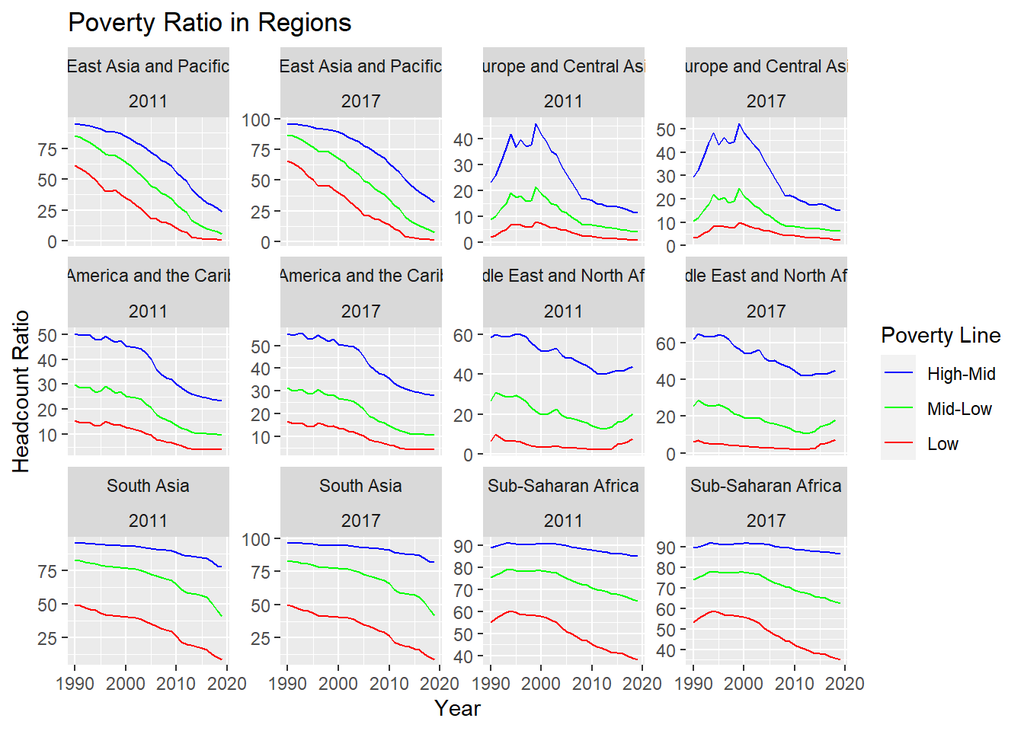

```r
#-------------------------------------------------------------------------------
#Just the 6 country regions
region_frame %>%
  ggplot (aes(x = year)) +
  geom_line(aes(y = headcount_ratio_international_povline, color = "red")) +
  geom_line(aes(y = headcount_ratio_lower_mid_income_povline, color = "green")) +
  geom_line(aes(y = headcount_ratio_upper_mid_income_povline, color = "blue")) +
  facet_wrap(~country+ppp_version, scales = "free_y") +
  labs(title = "Poverty Ratio in Regions", x = "Year", y = "Headcount Ratio", color = 'Poverty Line') +
  scale_color_manual(labels = c("High-Mid", "Mid-Low","Low"), values = c("blue", "green","red"))
```

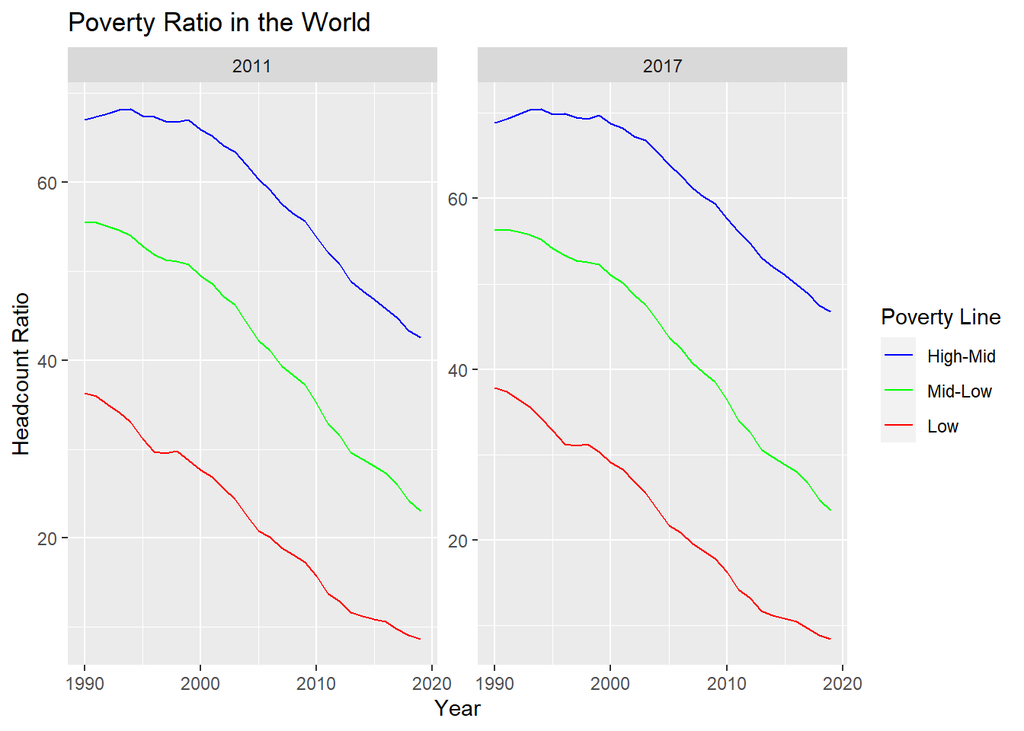

```r
#-------------------------------------------------------------------------------
# The whole world
world_frame %>%
  ggplot (aes(x = year)) +
  geom_line(aes(y = headcount_ratio_international_povline, color = "red")) +
  geom_line(aes(y = headcount_ratio_lower_mid_income_povline, color = "green")) +
  geom_line(aes(y = headcount_ratio_upper_mid_income_povline, color = "blue")) +
  facet_wrap(~ppp_version, scales = "free_y") +
  labs(title = "Poverty Ratio in the World", x = "Year", y = "Headcount Ratio", color = 'Poverty Line') +
  scale_color_manual(labels = c("High-Mid", "Mid-Low","Low"), values = c("blue", "green","red"))
```

#Total headcounts of those in poverty

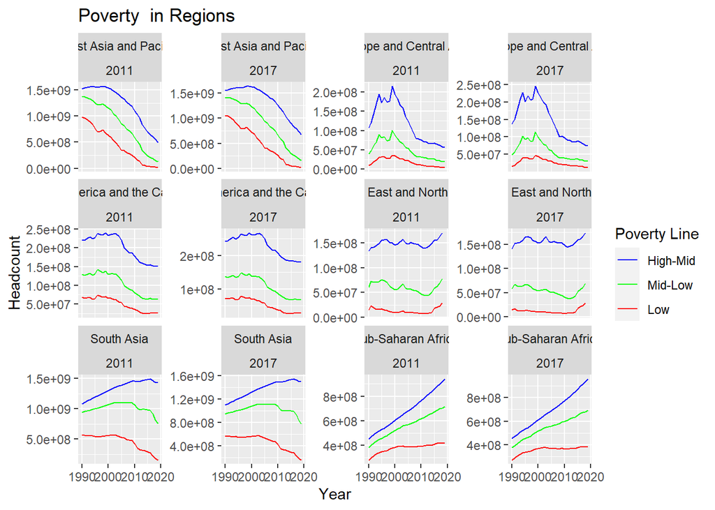

```r
#-------------------------------------------------------------------------------
# Just the 6 country regions
region_frame %>%
  ggplot (aes(x = year)) +
  geom_line(aes(y = headcount_international_povline, color = "red")) +
  geom_line(aes(y = headcount_lower_mid_income_povline, color = "green")) +
  geom_line(aes(y = headcount_upper_mid_income_povline, color = "blue")) +
  facet_wrap(~country+ppp_version, scales = "free_y") +
  labs(title = "Poverty  in Regions", x = "Year", y = "Headcount", color = 'Poverty Line') +
  scale_color_manual(labels = c("High-Mid", "Mid-Low","Low"), values = c("blue", "green","red"))
```

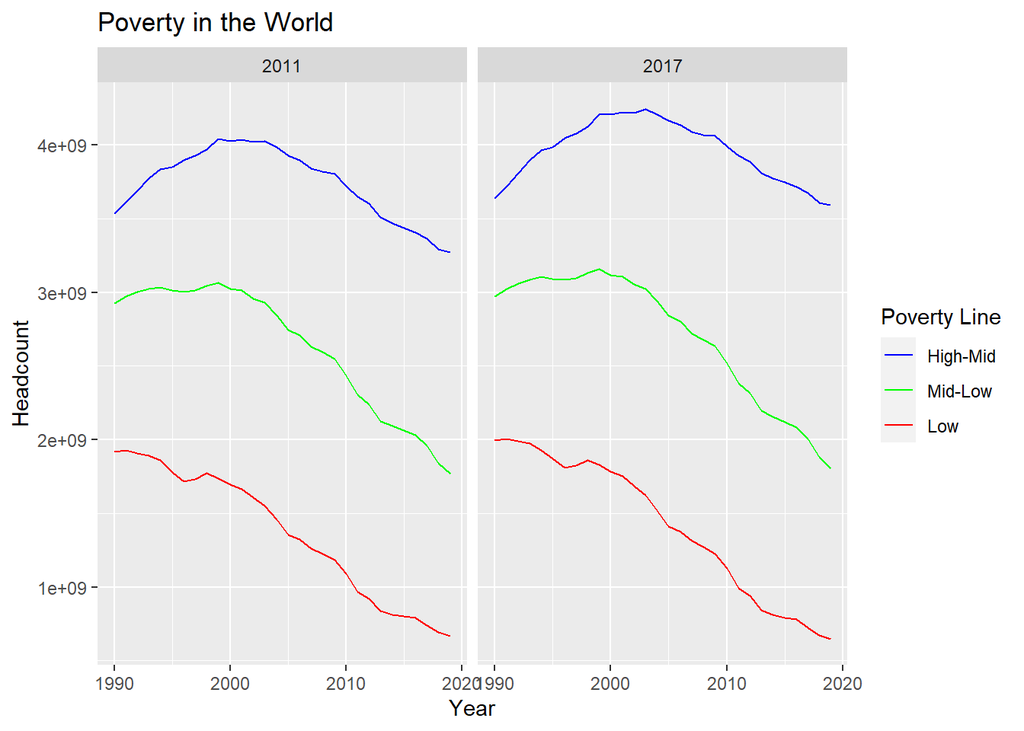

```r
#-------------------------------------------------------------------------------
# The whole world
world_frame %>%
  ggplot (aes(x = year)) +
  geom_line(aes(y = headcount_international_povline, color = "red")) +
  geom_line(aes(y = headcount_lower_mid_income_povline, color = "green")) +
  geom_line(aes(y = headcount_upper_mid_income_povline, color = "blue")) +
  facet_wrap(~ppp_version) +
  labs(title = "Poverty in the World", x = "Year", y = "Headcount", color = 'Poverty Line') +
  scale_color_manual(labels = c("High-Mid", "Mid-Low","Low"), values = c("blue", "green","red"))
```

#Let’s break up the region frame into each of the 6 regions

```r
reg_EastAsia_Pacific <- region_frame %>%
  filter(country == "East Asia and Pacific")

reg_Europe_CentralAsia <- region_frame %>%
  filter(country == "Europe and Central Asia")

reg_LatinAmerica_Caribbean <- region_frame %>%
  filter(country == "Latin America and the Caribbean")

reg_MidEast_NorthAfrica <- region_frame %>%
  filter(country == "Middle East and North Africa")

reg_South_Asia <- region_frame %>%
  filter(country == "South Asia")

reg_Subsaharan_Africa <- region_frame %>%
  filter(country == "Sub-Saharan Africa")
```

#Inference

#Linear regression to see how base poverty is affected by total population

```r
povlm_EastAsia_Pacific <- lm(headcount_international_povline ~ Total_Population, data = reg_EastAsia_Pacific)
summary(povlm_EastAsia_Pacific)
```

```
##
## Call:
## lm(formula = headcount_international_povline ~ Total_Population,
##     data = reg_EastAsia_Pacific)
##
## Residuals:
##        Min         1Q     Median         3Q        Max
## -108905333  -43326922    -517867   34169463  134318545
##
## Coefficients:
##                    Estimate Std. Error t value Pr(>|t|)
## (Intercept)       4.743e+09  9.524e+07   49.80   <2e-16 ***
## Total_Population -2.278e+02  5.061e+00  -45.02   <2e-16 ***
## ---
## Signif. codes:  0 '***' 0.001 '**' 0.01 '*' 0.05 '.' 0.1 ' ' 1
##
## Residual standard error: 56770000 on 58 degrees of freedom
## Multiple R-squared:  0.9722, Adjusted R-squared:  0.9717
## F-statistic:  2027 on 1 and 58 DF,  p-value: < 2.2e-16
```

```r
# R-Squared = 0.9722
cor(reg_EastAsia_Pacific$headcount_international_povline, reg_EastAsia_Pacific$Total_Population)
```

```
## [1] -0.9859914
```

```r
# Correlation = -0.9859914. squared = 0.972179
#-------------------------------------------------------------------------------
povlm_Europe_CentralAsia <- lm(headcount_international_povline ~ Total_Population, data = reg_Europe_CentralAsia)
summary(povlm_Europe_CentralAsia)
```

```
##
## Call:
## lm(formula = headcount_international_povline ~ Total_Population,
##     data = reg_Europe_CentralAsia)
##
## Residuals:
##       Min        1Q    Median        3Q       Max
## -20387209  -4691624   -126251   5297826  20507374
##
## Coefficients:
##                    Estimate Std. Error t value Pr(>|t|)
## (Intercept)       3.945e+08  6.092e+07   6.476 2.21e-08 ***
## Total_Population -7.847e+01  1.284e+01  -6.111 8.93e-08 ***
## ---
## Signif. codes:  0 '***' 0.001 '**' 0.01 '*' 0.05 '.' 0.1 ' ' 1
##
## Residual standard error: 8586000 on 58 degrees of freedom
## Multiple R-squared:  0.3917, Adjusted R-squared:  0.3812
## F-statistic: 37.35 on 1 and 58 DF,  p-value: 8.928e-08
```

```r
# R-Squared = 0.3917
cor(reg_Europe_CentralAsia$headcount_international_povline, reg_Europe_CentralAsia$Total_Population)
```

```
## [1] -0.6258561
```

```r
# Correlation = -0.6258561. squared = 0.3916959
#-------------------------------------------------------------------------------
povlm_LatinAmerica_Caribbean<- lm(headcount_international_povline ~ Total_Population, data = reg_LatinAmerica_Caribbean)
summary(povlm_LatinAmerica_Caribbean)
```

```
##
## Call:
## lm(formula = headcount_international_povline ~ Total_Population,
##     data = reg_LatinAmerica_Caribbean)
##
## Residuals:
##       Min        1Q    Median        3Q       Max
## -13925885  -5325697  -1378315   6264715  13068583
##
## Coefficients:
##                    Estimate Std. Error t value Pr(>|t|)
## (Intercept)       2.058e+08  8.319e+06   24.73   <2e-16 ***
## Total_Population -2.835e+01  1.516e+00  -18.70   <2e-16 ***
## ---
## Signif. codes:  0 '***' 0.001 '**' 0.01 '*' 0.05 '.' 0.1 ' ' 1
##
## Residual standard error: 7166000 on 58 degrees of freedom
## Multiple R-squared:  0.8577, Adjusted R-squared:  0.8552
## F-statistic: 349.6 on 1 and 58 DF,  p-value: < 2.2e-16
```

```r
# R-Squared = 0.8577
cor(reg_LatinAmerica_Caribbean$headcount_international_povline, reg_LatinAmerica_Caribbean$Total_Population)
```

```
## [1] -0.9261177
```

```r
# Correlation = -0.9261177. squared = 0.857694
#-------------------------------------------------------------------------------
povlm_MidEast_NorthAfrica <- lm(headcount_international_povline ~ Total_Population, data = reg_MidEast_NorthAfrica)
summary(povlm_MidEast_NorthAfrica)
```

```
##
## Call:
## lm(formula = headcount_international_povline ~ Total_Population,
##     data = reg_MidEast_NorthAfrica)
##
## Residuals:
##      Min       1Q   Median       3Q      Max
## -6821008 -4070487 -1599699  3359836 15641536
##
## Coefficients:
##                   Estimate Std. Error t value Pr(>|t|)
## (Intercept)      9.395e+06  4.793e+06   1.960   0.0551 .
## Total_Population 1.049e+00  1.552e+00   0.676   0.5021
## ---
## Signif. codes:  0 '***' 0.001 '**' 0.01 '*' 0.05 '.' 0.1 ' ' 1
##
## Residual standard error: 5505000 on 54 degrees of freedom
## Multiple R-squared:  0.008386,   Adjusted R-squared:  -0.009977
## F-statistic: 0.4567 on 1 and 54 DF,  p-value: 0.5021
```

```r
# R-Squared = 0.008386
cor(reg_MidEast_NorthAfrica$headcount_international_povline, reg_MidEast_NorthAfrica$Total_Population)
```

```
## [1] 0.09157423
```

```r
# correlation = 0.09157423. squared = 0.008385839
#-------------------------------------------------------------------------------
povlm_South_Asia <- lm(headcount_international_povline ~ Total_Population, data = reg_South_Asia)
summary(povlm_South_Asia)
```

```
##
## Call:
## lm(formula = headcount_international_povline ~ Total_Population,
##     data = reg_South_Asia)
##
## Residuals:
##        Min         1Q     Median         3Q        Max
## -121699098  -45663910  -22716894   82054096  100896183
##
## Coefficients:
##                    Estimate Std. Error t value Pr(>|t|)
## (Intercept)       1.232e+09  6.905e+07   17.85  < 2e-16 ***
## Total_Population -5.207e+01  4.484e+00  -11.61 1.52e-15 ***
## ---
## Signif. codes:  0 '***' 0.001 '**' 0.01 '*' 0.05 '.' 0.1 ' ' 1
##
## Residual standard error: 70390000 on 48 degrees of freedom
## Multiple R-squared:  0.7375, Adjusted R-squared:  0.732
## F-statistic: 134.9 on 1 and 48 DF,  p-value: 1.519e-15
```

```r
# R-Squared = 0.7375
cor(reg_South_Asia$headcount_international_povline, reg_South_Asia$Total_Population)
```

```
## [1] -0.8587743
```

```r
# Correlation = -0.8587743. squared = 0.7374933
#-------------------------------------------------------------------------------
povlm_Subsaharan_Africa <- lm(headcount_international_povline ~ Total_Population, data = reg_Subsaharan_Africa)
summary(povlm_Subsaharan_Africa)
```

```
##
## Call:
## lm(formula = headcount_international_povline ~ Total_Population,
##     data = reg_Subsaharan_Africa)
##
## Residuals:
##       Min        1Q    Median        3Q       Max
## -58941860 -17735788   6548817  14893987  35815276
##
## Coefficients:
##                   Estimate Std. Error t value Pr(>|t|)
## (Intercept)      2.561e+08  1.256e+07  20.383  < 2e-16 ***
## Total_Population 1.459e+01  1.588e+00   9.189 6.49e-13 ***
## ---
## Signif. codes:  0 '***' 0.001 '**' 0.01 '*' 0.05 '.' 0.1 ' ' 1
##
## Residual standard error: 21850000 on 58 degrees of freedom
## Multiple R-squared:  0.5928, Adjusted R-squared:  0.5858
## F-statistic: 84.43 on 1 and 58 DF,  p-value: 6.486e-13
```

```r
# R-Squared = 0.5928
cor(reg_Subsaharan_Africa$headcount_international_povline, reg_Subsaharan_Africa$Total_Population)
```

```
## [1] 0.769925
```